# Elements of AI Practicum 1.2

Eploratory Data Analysis

The left side of the brain is linked to logical thinking, analytical skills, and precision[^1]. These traits are vital for footballers, particularly in strategic planning and on-field decision-making. A player with strong left-brain dominance can swiftly analyze the game, anticipate opponents’ moves, and make precise passes. Consequently, left-footed players often excel in offensive roles due to their ability to deliver accurate crosses, take precise shots, and create unexpected plays, making them valuable assets as left wingers or forwards.

### Hypothesis Formulation

We hypothesize that left-footed players are more commonly engaged in offensive positions due to their cognitive advantage to read the game. But is this really true, or just a myth?

For example, Lionel Messi, one of the greatest footballers of all time, is known for his exceptional left-footed skills. His ability to create unexpected plays has made him a key player for both FC Barcelona and the Argentina national team. Similarly, Gareth Bale excels in offensive roles for clubs like Real Madrid and Tottenham Hotspur, and other left-footed players like Arjen Robben and Ryan Giggs created memorable moments in football history by absolutely dominating the field.

### Data

To validate or refute this hypothesis, you will delve into the football player records from the 2022 season of the FIFA dataset. The relevant file, `players_22.csv`, is accessible on Kaggle[^2] and is also included as a local copy with your study materials for your convenience.

### Supporting Evidence From EDA

Support for this hypothesis comes from analyzing the frequency of left-footed players in top-tier European teams. This insight is typically gathered through exploratory data analysis, which is the first step before attempting to prove any hypothesis. You can examine the number of left-footed players in each league and visualize this proportion using a stacked bar plot.

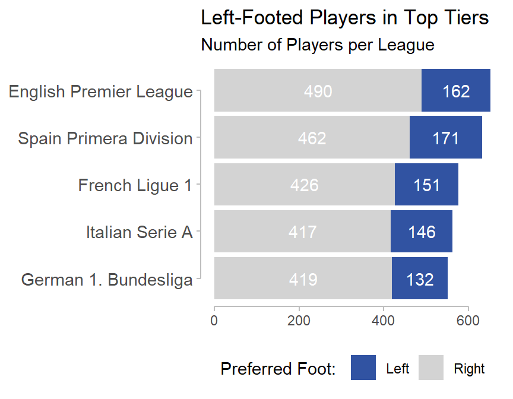

The frequency of left-footed players is thrice higher than would be expected if it matches the frequency of left-footed people from a general population. Your task is to use EDA techniques to find out if these players are engaged in offensive positions more than they would be in defensive positions. Additionally, analyze their market value, wages and transfer fees to determine if being a left-footed offensive player gives them an edge in the market.

You should also also check if young left-footed players have higher potential for improvement compared to their right-footed counterparts and hence are valuable assets to invest into. By visualizing some of these data with simple charts, you should get a clearer picture of how left-footed players stack up in the world.

### Objective(s)

- Grasp the process of hypothesis testing through data exploration.
- Apply functional programming where appropriate.
- Apply the concept of exploratory graphics with ggplot2 and gain hands-on experience applying it in data mining.

### What Do I Need To Know Before Starting?

Before attempting this practicum, you should be well-versed in data manipulation functions from Tidyverse packages such as dplyr and tidyr. Some knowledge of the grammar of graphics can be useful, and familiarity with functional programming is highly recommended. Consider completing **Tutorial 4.1** through **4.3**, as well as **Tutorials 5.1** and **5.2**, first. Grammar of graphics can be eventually replaced with base R plotting functions.

### Make Sure To…

- use the text from above to specify each task and develop a plan how to accomplish it. You’ll need to classify players, get counts, and compare groups, etc. Avoid tackling all problems simultaneously; instead, break down a complex task into simpler ones.
- first, solve each problem conceptually with pseudo-code, then create the appropriate R code to complete the task. Do not use large language models like ChatGPT to solve these tasks; instead, write the code yourself.
- start by analyzing player positions. Define categories for offense, defense, and midfielders. There are up to 30 FIFA positions available as codes[^3]. The classification of positions into groups is eventually up to you, but consider the following codes for each category: offense includes forwards (LF, CF, RF), wingers (LW, RW), and strikers (LS, ST, RS). Defensive players include rear wingers (LWB, RWB), center backs (LCB, CB, RCB), and back flanks (LB, RB). Midfielders can play either at forward positions (LM, LAM, CM, RM, RAM), as central attacking midfielders (CAM), or in defense (CDM, DM, LDM and RDM). Goalkeepers form a separate category.
- keep in mind that a player can play in multiple positions, so consider appropriate measures to handle this situation. This is particularly important if you are using `player_positions` to assign a player. Alternatively, you can use `club_position` for the same task, but be aware that not all players are currently active; many are either in reserve (RES) or substitutes (SUB). Consequently, the total number of players available for analysis will decrease.
- avoid Python-style programming, which often involves creating numerous intermediary objects and complex loops. This approach can obscure the clarity of your code, making it difficult to discern inputs and outputs, and it tends to be less expressive. Instead, strive to adhere to the tidyverse style, which emphasizes linear sets of transformations for cleaner and more readable code. Use functional programming where appropriate.
- visualize proportion and count data using suitable plots, like a stacked barplot. Use color-coding to differentiate between various player categories. Eventually, think about a suitable statistical test to formally prove the hypothesis.

### Footnotes

[^1]: Left-footnotes in football often correlates with left-handedness in the general population. Studies indicate that approximately 10.6% of people worldwide are left-handed. Similarly, a notable portion of left-footed football players are also left-handed. However, only about 60.1% of left-handers are left-footed2. This connection suggests that many individuals who prefer using their left hand also favor their left foot, though the correlation isn’t absolute.
[^2]: https://www.kaggle.com/datasets/stefanoleone992/fifa-22-complete-player-dataset
[^3]: https://fifauteam.com/fc-24-positions-guide/